# Data science per psicologi - demo 25.02

Corrado Caudek

2022-04-15

```r
suppressPackageStartupMessages({
  library("here")
  library("tidyverse")
  library("bayesplot")
  library("rstan")
  library("cmdstanr")
  library("posterior")
})

rstan_options(auto_write = TRUE) # avoid recompilation of models
options(mc.cores = parallel::detectCores()) # parallelize across all CPUs
Sys.setenv(LOCAL_CPPFLAGS = "-march=native") # improve execution time

theme_set(bayesplot::theme_default(base_size = 12))
bayesplot::color_scheme_set("gray")
set.seed(84735)

knitr::opts_chunk$set(
  collapse = TRUE,
  tidy = 'styler',
  fig.width = 6,
  fig.asp = 0.618 # 1 / phi
)
```

# Confronto tra le medie di due gruppi in Stan

In questo demo ci poniamo il problema del confronto tra le medie di due gruppi usando Stan.

Useremo i dati contenuti nel pacchetto `sur`.

```r
library("sur")
data(Brainsz)
glimpse(Brainsz)
```

```
## Rows: 40
## Columns: 7
## $ ID     <dbl> 2, 3, 4, 9, 10, 12, 13, 18, 20, 21, 22, 24, 26, 28, 32, 33, 34,…
## $ GENDER <fct> Male, Male, Male, Male, Male, Male, Male, Male, Male, Male, Mal…
## $ FSIQ   <dbl> 140, 139, 133, 89, 133, 141, 135, 100, 80, 83, 97, 139, 141, 10…
## $ VIQ    <dbl> 150, 123, 129, 93, 114, 150, 129, 96, 77, 83, 107, 145, 145, 96…
## $ PIQ    <dbl> 124, 150, 128, 84, 147, 128, 124, 102, 86, 86, 84, 128, 131, 11…
## $ MRI    <dbl> 1001121, 1038437, 965353, 904858, 955466, 1079549, 924059, 9450…
## $ IQDI   <fct> Higher IQ, Higher IQ, Higher IQ, Lower IQ, Higher IQ, Higher IQ…
```

Riporto qui sotto la descrizione del set di dati.

> The data are based on a study by Willerman et al. (1991) of the relationships between brain size, gender, and intelligence. The research participants consisted of 40 right-handed introductory psychology students with no history of alcoholism, unconsciousness, brain damage, epilepsy, or heart disease who were selected from a larger pool of introductory psychology students with total Scholastic Aptitude Test Scores higher than 1350 or lower than 940. The students in the study took four subtests (Vocabulary, Similarities, Block Design, and Picture Completion) of the Wechsler (1981) Adult Intelligence Scale-Revised. Among the students with Wechsler full-scale IQ’s less than 103, 10 males and 10 females were randomly selected. Similarly, among the students with Wechsler full-scale IQ’s greater than 130, 10 males and 10 females were randomly selected, yielding a randomized blocks design. MRI scans were performed at the same facility for all 40 research participants to measure brain size. The scans consisted of 18 horizontal MRI images. The computer counted all pixels with non-zero gray scale in each of the 18 images, and the total count served as an index for brain size. The dataset and description are adapted from the Data and Story Library (DASL) website.

Mi concentrerò sulla relazione tra grandezza del cervello e genere. Sappiamo che la grandezza del cervello tende ad essere maggiore per i maschi rispetto alle femmine – questo non significa che i maschi abbiano un QI maggiore delle femmine.

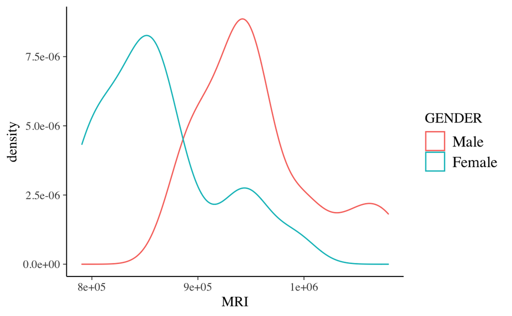

```r
Brainsz %>%
  ggplot(aes(x = MRI, group = GENDER, color = GENDER)) +
  geom_density()
```

I dati rappresentati nel diagramma precedente suggeriscono che, in questo piccolo campione, la distribuzione dei valori MRI sembra essere spostata verso valori maggiori per i maschi rispetto alle femmine.

Per semplificare l’analisi, standardizzo i dati.

```r
Brainsz$mri <- scale(Brainsz$MRI) %>%
  as.numeric()
```

Inoltre, creo una variabile dicotomica che assume valore 0 per le femmine e 1 per i maschi.

```r
Brainsz$gender <- ifelse(Brainsz$GENDER == "Female", 0, 1)
Brainsz$gender
```

```
##  [1] 1 1 1 1 1 1 1 1 1 1 1 1 1 1 1 1 1 1 1 1 0 0 0 0 0 0 0 0 0 0 0 0 0 0 0 0 0 0
## [39] 0 0
```

### I dati in Stan

Inserisco i dati in una lista così come richiesto da Stan:

```r
data_list <- list(
  N = length(Brainsz$mri),
  x = Brainsz$gender,
  y = Brainsz$mri
)

data_list
```

```
## $N
## [1] 40
##
## $x
##  [1] 1 1 1 1 1 1 1 1 1 1 1 1 1 1 1 1 1 1 1 1 0 0 0 0 0 0 0 0 0 0 0 0 0 0 0 0 0 0
## [39] 0 0
##
## $y
##  [1]  1.27785531  1.79411074  0.78301599 -0.05391380  0.64623237  2.36288266
##  [7]  0.21172615  0.50265592 -0.27215609 -0.22598972 -0.03894466  0.63982691
## [13]  0.36992587  2.12648925  0.56492588  1.23363963 -0.39799647  0.56224195
## [19]  0.29413942  0.37503087 -1.27034307  0.59198654  0.27730260  1.14205396
## [25] -0.75394930 -1.03603870 -0.72331929 -0.41307628 -0.60031502 -0.78181237
## [31] -1.39363786 -1.63437536 -1.06503622 -1.52379466 -1.59383971 -0.58234376
## [37] -0.70519584 -1.02945339  0.54385564 -0.20436609
```

Definizione il modello in linguaggio Stan.

```r
model_string <- "
  data {
    int<lower=0> N;     // number of data points
    vector[N] x;    // covariate / predictor
    vector[N] y;    // target
  }
  parameters {
    real alpha;          // intercept
    real beta;           // slope
    real<lower=0> sigma; // standard deviation is constrained to be positive
  }
  transformed parameters {
    // deterministic transformation of parameters and data
    vector[N] mu = alpha + beta*x;      // linear model
  }
  model {
    alpha ~ normal(0, 2.5);    // prior
    beta ~ normal(0, 2.5);     // prior
    sigma ~ normal(0, 10);      // as sigma is constrained to be positive,
                               // this is same as half-normal prior
    y ~ normal(mu, sigma);     // likelihood
  }
"
```

Salvo il modello Stan in un file.

```r
writeLines(model_string, con = "code/lmod_1.stan")
file <- file.path("code", "lmod_1.stan")
```

Compilo il modello.

```r
mod <- cmdstan_model(file)
```

Eseguo il campionamento MCMC.

```r
fit <- mod$sample(
  data = data_list,
  iter_sampling = 4000L,
  iter_warmup = 2000L,
  seed = 84735,
  chains = 4L,
  refresh = 0,
  thin = 1
)
```

Esamino i risultati del campionamento MCMC.

```r
post <- fit$draws()
```

```r
# estraggo solo le stime a posteriori dei parametri di interesse
post_parms <- subset_draws(post, c("alpha", "beta", "sigma"))
posterior::summarise_draws(post_parms)
```

```
## # A tibble: 3 × 10
##   variable   mean median     sd    mad     q5    q95  rhat ess_bulk ess_tail
##   <chr>     <dbl>  <dbl>  <dbl>  <dbl>  <dbl>  <dbl> <dbl>    <dbl>    <dbl>
## 1 alpha    -0.624 -0.625 0.181  0.178  -0.919 -0.327  1.00    8489.    8763.
## 2 beta      1.25   1.26  0.255  0.253   0.835  1.67   1.00    8130.    8506.
## 3 sigma     0.801  0.792 0.0956 0.0920  0.661  0.971  1.00    9518.    9176.
```

Trovo l’intervallo di credibilità al 95%.

```r
posterior::summarise_draws(
  post_parms,
  ~ quantile(.x, probs = c(0.025, 0.975))
)
```

```
## # A tibble: 3 × 3
##   variable `2.5%` `97.5%`
##   <chr>     <dbl>   <dbl>
## 1 alpha    -0.977  -0.272
## 2 beta      0.753   1.75
## 3 sigma     0.642   1.01
```

I risultati ottenuti sono molto simili a quelli trovati con l’approccio frequentista.

```r
fm <- lm(mri ~ gender, Brainsz)
summary(fm)
```

```
##
## Call:
## lm(formula = mri ~ gender, data = Brainsz)
##
## Residuals:
##     Min      1Q  Median      3Q     Max
## -1.0358 -0.4786 -0.1008  0.2769  1.7798
##
## Coefficients:
##             Estimate Std. Error t value Pr(>|t|)
## (Intercept)  -0.6378     0.1729  -3.688 0.000704 ***
## gender        1.2756     0.2446   5.216 6.76e-06 ***
## ---
## Signif. codes:  0 '***' 0.001 '**' 0.01 '*' 0.05 '.' 0.1 ' ' 1
##
## Residual standard error: 0.7734 on 38 degrees of freedom
## Multiple R-squared:  0.4172, Adjusted R-squared:  0.4019
## F-statistic:  27.2 on 1 and 38 DF,  p-value: 6.758e-06
```

Esamino il “mixing” delle catene.

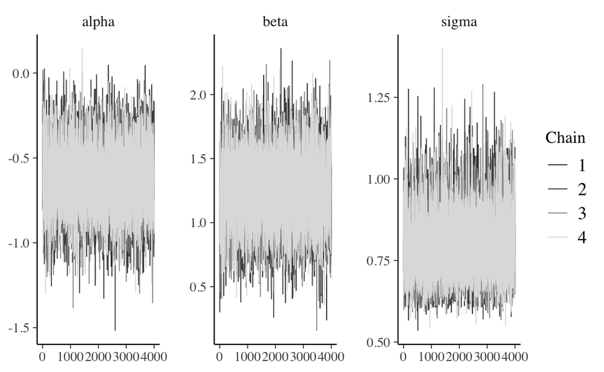

```r
bayesplot::mcmc_trace(post, pars = c("alpha", "beta", "sigma"))
```

Creo un grafico della distribuzione a posteriori dei tre parametri.

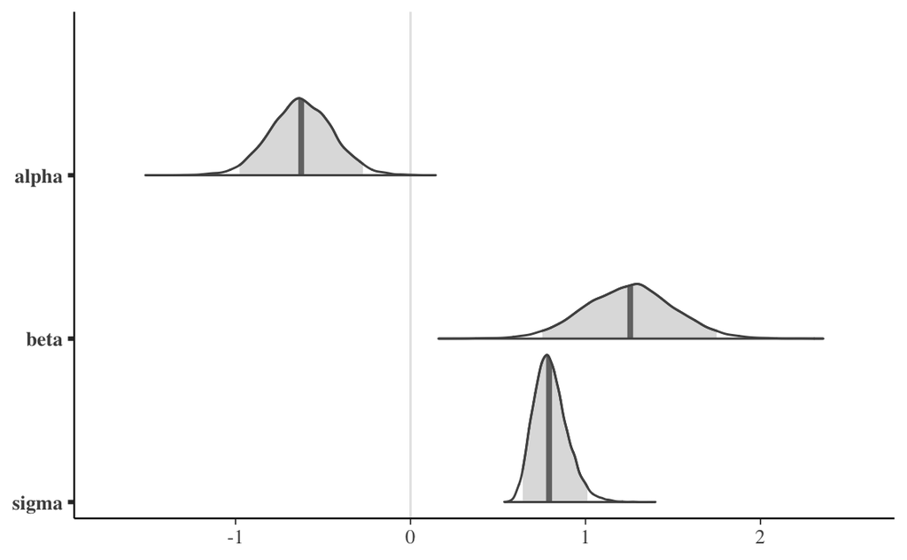

```r
bayesplot::mcmc_areas(post, pars = c("alpha", "beta", "sigma"), prob = 0.95)
```

Dato che, nel caso presente, abbiamo solo standardizzato $y$ (ma non $x$), il parametro $\alpha$ non è uguale a 0. Non ha però alcun interesse.

Il parametro di interesse è $\beta$. Questo ci dice che, all’aumentare di un’unità (da 0 a 1) della variabile $x$ (genere; ovvero, passando dalle femmine ai maschi), la grandezza del cervello aumenta, in media di 1.25 deviazioni standard, 95% CI [0.75, 1.75].

Questo aumento di grandezza del cervello, però, non corrisponde ad una differenza nel FSIQ tra i generi.

```r
data_list2 <- list(
  N = length(Brainsz$gender),
  x = Brainsz$gender,
  y = scale(Brainsz$FSIQ) %>% as.numeric()
)

data_list
```

```
## $N
## [1] 40
##
## $x
##  [1] 1 1 1 1 1 1 1 1 1 1 1 1 1 1 1 1 1 1 1 1 0 0 0 0 0 0 0 0 0 0 0 0 0 0 0 0 0 0
## [39] 0 0
##
## $y
##  [1]  1.27785531  1.79411074  0.78301599 -0.05391380  0.64623237  2.36288266
##  [7]  0.21172615  0.50265592 -0.27215609 -0.22598972 -0.03894466  0.63982691
## [13]  0.36992587  2.12648925  0.56492588  1.23363963 -0.39799647  0.56224195
## [19]  0.29413942  0.37503087 -1.27034307  0.59198654  0.27730260  1.14205396
## [25] -0.75394930 -1.03603870 -0.72331929 -0.41307628 -0.60031502 -0.78181237
## [31] -1.39363786 -1.63437536 -1.06503622 -1.52379466 -1.59383971 -0.58234376
## [37] -0.70519584 -1.02945339  0.54385564 -0.20436609
```

Non serve compilare il modello in quanto lo stesso modello usato in precedenza (ho cambiato solo i dati).

Eseguo il campionamento MCMC.

```r
fit2 <- mod$sample(
  data = data_list2,
  iter_sampling = 4000L,
  iter_warmup = 2000L,
  seed = 84735,
  chains = 4L,
  refresh = 0,
  thin = 1
)
```

Esamino i risultati del campionamento MCMC.

```r
post2 <- fit2$draws()
```

```r
# estraggo solo le stime a posteriori dei parametri di interesse
post2_parms <- subset_draws(post2, c("alpha", "beta", "sigma"))
posterior::summarise_draws(post2_parms)
```

```
## # A tibble: 3 × 10
##   variable    mean  median    sd   mad     q5   q95  rhat ess_bulk ess_tail
##   <chr>      <dbl>   <dbl> <dbl> <dbl>  <dbl> <dbl> <dbl>    <dbl>    <dbl>
## 1 alpha    -0.0612 -0.0596 0.237 0.234 -0.452 0.330  1.00    9107.    9963.
## 2 beta      0.123   0.123  0.332 0.325 -0.421 0.671  1.00    9093.   10151.
## 3 sigma     1.05    1.03   0.128 0.123  0.861 1.27   1.00    9434.    8973.
```

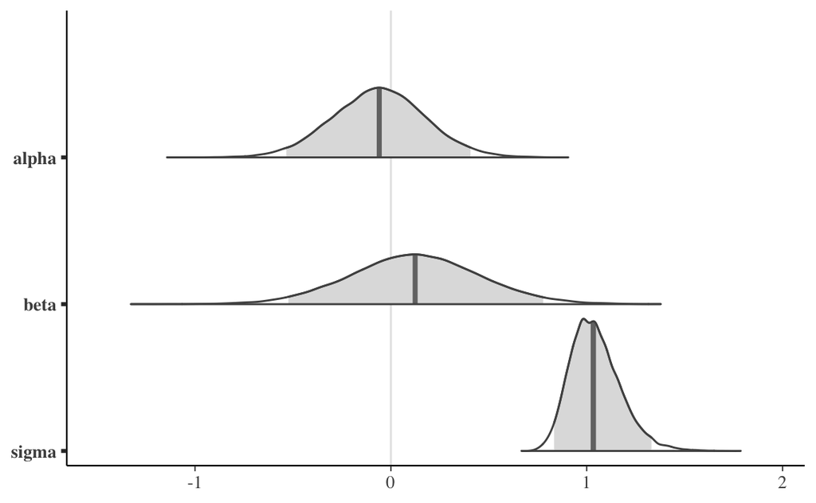

```r
bayesplot::mcmc_areas(post2, pars = c("alpha", "beta", "sigma"), prob = 0.95)
```

La distribuzione a posteriori di $\beta$ della figura precedente indica come l’intervallo di credibilità al 95% include il valore 0. Non vi è dunque alcuna evidenza di differenze nel FSIQ tra maschi e femmine.

## Conclusioni

La letteratura che descrive lo studio dell’intelligenza ha conciliato questi risultati apparentemente contraddittori (vi è un’associazione positiva tra grandezza del cervello e IQ; la grandezza del cervello è maggiore per i maschi rispetto alle femmine; non c’è evidenza di differenza nel QI in funzione del genere) nel modo seguente. Anche se il cervello delle femmine, in media, è più piccolo di quello dei maschi, *l’efficienza* delle computazioni neurali delle femmine è maggiore di quella dei maschi.